# HW_proteomics

Daria Ganaeva

20 04 2024

Upload libraries

```r
library(limma)
library(ape)
library(dendextend)
library(RColorBrewer)
library(pvclust)
library(gplots)
library(NMF)
library(vegan)
library(Biobase)
library(DT)
library(ggplot2)
library(impute)
library(ggrepel)
library(clusterProfiler)
library(org.Hs.eg.db)
```

Upload the data

```r
data <- read.csv("peaks_data.csv")
```

View and check for NAs visually

```r
#View(data)
```

We have no empty samples, but there are missing (NA) values

Let’s check if we have any duplicate genes and genes with half and more missing values and filter them out

```r
data_d <- data[which(!duplicated(data$Gene_id)), ]
rownames(data_d) <- data_d$Gene_id

col_number <- length(colnames(data_d[, -c(1:3)]))

nas <- rowSums(is.na(data_d[, names(data_d) %in% colnames(data_d[, -c(1:3)])]))

with_NA <- rownames(data_d)[nas > (col_number/2)]

data_f <- data_d[!rownames(data_d) %in% with_NA,]

nrow(data)
```

```
## [1] 3634
```

```r
nrow(data_d)
```

```
## [1] 3582
```

```r
nrow(data_f)
```

```
## [1] 2271
```

Now we can proceed to KNN imputation:

```r
data_count <- as.matrix(data_f[, names(data_f) %in% colnames(data_f[, -c(1:3)])])
data_count <- t(data_count)
knn <- impute.knn(data_count, k = 5)
data_knn <- knn$data
data_knn <- t(as.matrix(data_knn))
head(data_knn, 2)
```

```
##             BT_1       BT_2       BT_3       BT_4       BT_5       BT_6
## AHNAK 3208900000 2374900000 2880800000 1909900000 3236700000 3255400000
## PLEC  1943300000 2154300000 1846100000 2267400000 1739200000 3055300000
##             BT_7       BT_8       BT_9      BT_10      BT_11      BT_12
## AHNAK 3441100000 2948000000 2548700000 1770600000 2411100000 2038000000
## PLEC   793750000 1187500000 1402000000 1922900000 1803500000 2018600000
##            BT_13      BT_14      CJK_1     CJK_2      CJK_3      CJK_4
## AHNAK 3105200000 2409800000 2296400000 201810000 5520600000 1276900000
## PLEC  1165800000 1869100000 1098600000 260490000 1539300000  831110000
##            CJK_5      CJK_6      CJK_7      CJK_8      CJK_9     CJK_10
## AHNAK 3526700000 1872000000 5389500000 1107000000 5859000000 3463400000
## PLEC  1355200000 1775800000 1518800000  648160000 3561400000 2864700000
##           CJK_11     CJK_12     CJK_13     CJK_14     CJK_16     CJK_17
## AHNAK 7258500000 1182700000 2700500000 2351600000 1754100000 1479000000
## PLEC  3362500000 1242900000 1354800000 1511200000  984310000 1251900000
##           CJK_18    CJK_19     CJK_20
## AHNAK 1692100000 595420000 1666300000
## PLEC  1832600000 292760000 1066500000
```

Check the distribution of the data

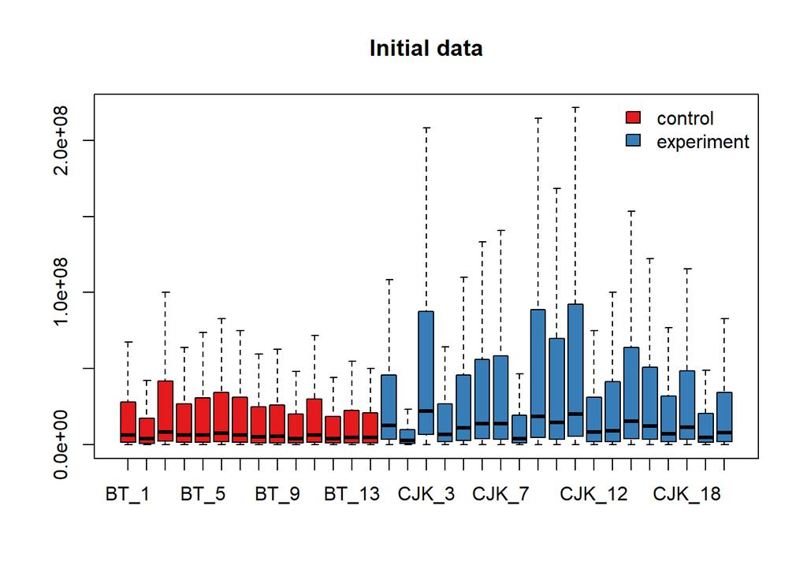

```r
pal <- brewer.pal(n = 9, name = "Set1")
data_experiment <- as.factor(c("control", "control", "control", "control", "control", "control", "control", "control", "control", "control", "control", "control", "control", "control", "experiment", "experiment", "experiment", "experiment", "experiment", "experiment", "experiment", "experiment", "experiment", "experiment", "experiment", "experiment", "experiment", "experiment", "experiment", "experiment", "experiment", "experiment", "experiment"))

cols <- pal[data_experiment]
boxplot(data_knn, outline = FALSE, main = "Initial data", col = cols)
legend("topright", levels(data_experiment), fill = pal, bty = "n", xpd = T)
```

log transformation + normalization

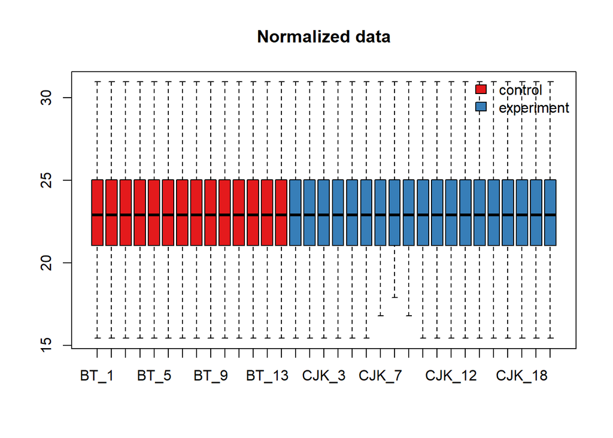

```r
data_log <- log2(data_knn + 0.1)
data_norm <- normalizeQuantiles(as.matrix(data_log))
boxplot(data_norm, outline = FALSE, main = "Normalized data", col = cols)
legend("topright", levels(data_experiment), fill = pal, bty = "n", xpd = T)
```

Search for batch effect

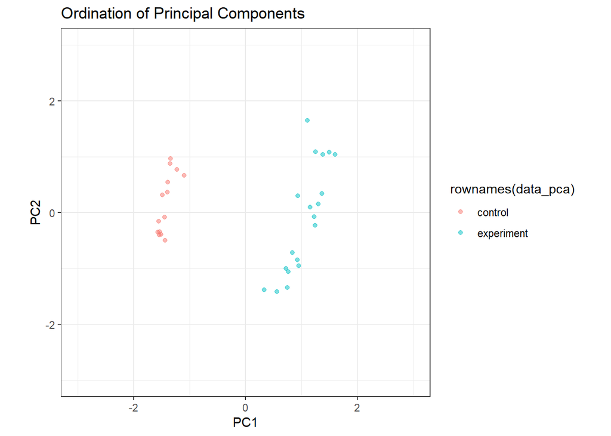

```r
data_pca <- t(data_norm)
terapod_pca <- rda(data_pca, scale = TRUE)

rownames(data_pca) <- data_experiment

data_scores <- data.frame(data_pca,
                        scores(terapod_pca, display = "sites", choices = c(1, 2, 3), scaling = "sites"))

p_scores <- ggplot(data_scores, aes(x = PC1, y = PC2)) +
  geom_point(aes(color = rownames(data_pca)), alpha = 0.5) +
  coord_equal(xlim = c(-3, 3), ylim = c(-3, 3)) + ggtitle(label = "Ordination of Principal Components") + theme_bw()
p_scores
```

We can see that our samples are clustered together based on their group status. We can conclude that no batch-effect is captured by this plot. We can continue the analysis

let’s build MA-plot to visually estimate the expression

```r
maplot <- function(X1, X2, pch = 21, main = "MA-plot", xlab = "Average log-expression", ylab = "Expression log-ratio", lpars = list(col = "blue", lwd = 2), ...){
  X <- (rowMeans(X2) + rowMeans(X1)) / 2
  Y <- rowMeans(X2) - rowMeans(X1)
  scatter.smooth(x = X, y = Y, main = main, pch = pch, xlab = xlab, ylab = ylab, lpars = lpars, ...)
  abline(h = c(-1, 0, 1), lty = c(2, 1, 2))
}
```

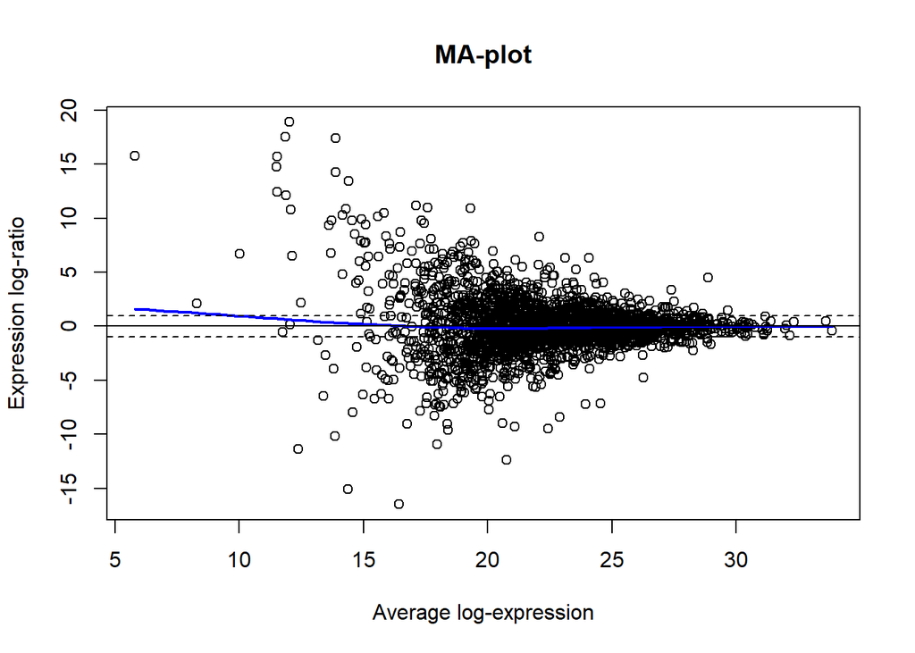

```r
maplot(data_norm[,1:14], data_norm[,15:33])
```

DE analysis

```r
# Expression data
expr_data <- as.matrix(data_norm)

# Sample data
pheno_data <- data.frame(data_experiment)
rownames(pheno_data) <- colnames(data_norm)
pheno_metadata <- data.frame(
  labelDescription = c("Experimental condition"),
  row.names=c("Condition"))
pheno_data <- new("AnnotatedDataFrame",
                 data = pheno_data,
                 varMetadata = pheno_metadata)

# Protein data
feature_data <- data.frame(Prot = rownames(expr_data))
rownames(feature_data) <- rownames(expr_data)
feature_metadata <- data.frame(
  labelDescription = c("Protein name"),
  row.names = c("Protein"))
f_data <- new("AnnotatedDataFrame",
              data = feature_data,
              varMetadata = feature_metadata)

# Merge together
exp_set <-
  ExpressionSet(assayData = expr_data,
                phenoData = pheno_data,
                featureData = f_data)
```

```r
X <- model.matrix(~ data_experiment, pData(exp_set))
fit <- lmFit(exp_set, design = X, method = "robust", maxit = 1000)
efit <- eBayes(fit)
```

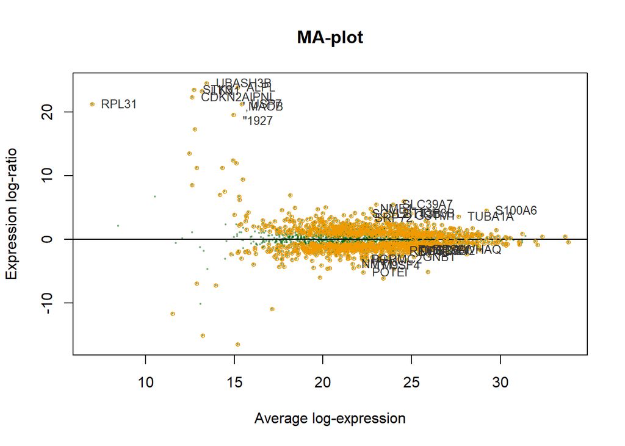

```r
MA_limma <- function(efit, coef, n = 10, signif = TRUE, fdr = 0.05, lfc = 0, text = TRUE, cex.text = 0.8, col.text = "grey20", main = "MA-plot", xlab = "Average log-expression", ylab = "Expression log-ratio", pch = 19, pch.signif = 21, col = "darkgreen", alpha = 0.3, cex = 0.3, ...){

  R <- efit$coefficients[, coef]
  I <- efit$Amean

  col_btransp <- adjustcolor(col, alpha.f = alpha)

  plot(I, R, cex = cex, main = main, pch = pch, xlab = xlab, ylab = ylab, col = col_btransp, ...)
  abline(h = 0)

  if(signif){
    sign <- p.adjust(efit$p.value[, coef], method = "BH") <= fdr
    large <- abs(efit$coefficients[, coef]) >= lfc
    points(I[sign & large], R[sign & large], cex = cex*2, col = "orange2", pch = pch.signif)
  }

  if(text){
    ord <- order(efit$lods[, coef], decreasing = TRUE)
    top_n <- ord[1:n]
    text(I[top_n], R[top_n], labels = efit$genes[top_n, ], pos = 4, cex = cex.text, col = col.text)
  }
}


MA_limma(efit, coef = 2, n = 30)
```

Collect DE proteins

```r
my_list <- topTable(efit, coef = 2, n = 100)
dif_exp_set <- exp_set[fData(exp_set)$Prot %in% my_list$Prot, ]
```

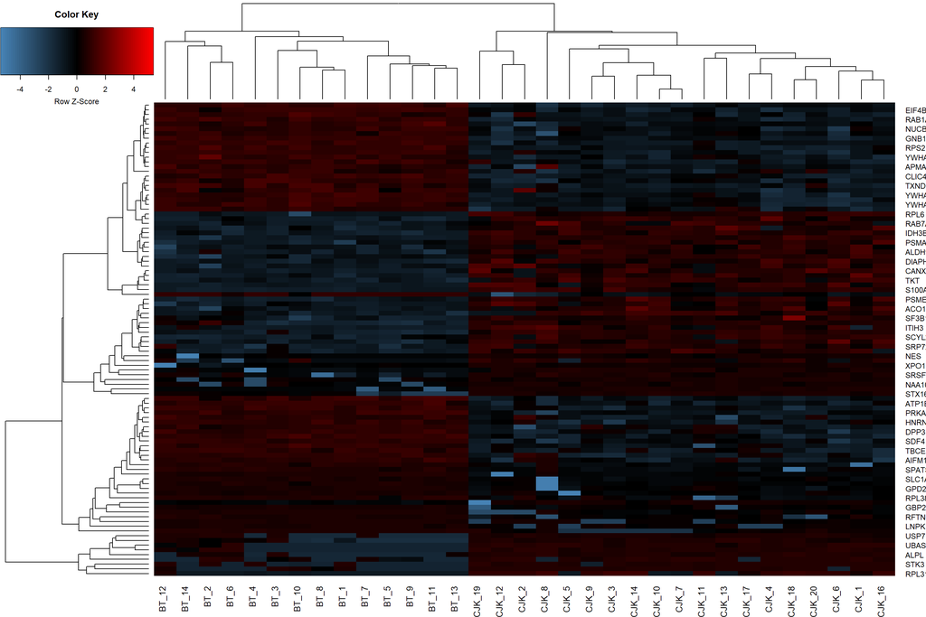

```r
dat <- as.matrix(exprs(dif_exp_set))

pal_blue_red <- colorpanel(75, low = "steelblue", mid = "black", high = "red")
heatmap.2(dat, col = pal_blue_red, scale = "row", key = TRUE, symkey = FALSE, density.info = "none", trace = "none", cexRow = 0.9, cexCol = 1, margins = c(4, 3), keysize = 0.8, key.par = list(mar = c(3, 0.1, 3, 0.1)))
```

```r
topTable(efit, coef = 2)
```

```
##                  Prot     logFC   AveExpr         t      P.Value    adj.P.Val
## STK3             STK3 23.496281 12.717434 100.31391 1.128840e-42 2.563597e-39
## UBASH3B       UBASH3B 24.496390 13.446655  71.14518 9.225171e-38 1.047518e-34
## RPL31           RPL31 21.278173  6.988635  69.88537 1.659365e-37 1.256139e-34
## LTN1             LTN1 23.284760 13.183477  67.95317 4.168128e-37 2.366455e-34
## CDKN2AIPNL CDKN2AIPNL 22.313142 12.613264  43.89777 6.714677e-31 3.049806e-28
## TM9SF4         TM9SF4 -4.037216 22.404285 -26.93010 4.494542e-24 1.701184e-21
## NME1             NME1  4.857686 22.696927  26.66942 6.115366e-24 1.984000e-21
## GSTM1           GSTM1  3.767080 24.667796  24.95514 4.974563e-23 1.412154e-20
## ALPL             ALPL 23.874291 15.190665  24.72835 6.628259e-23 1.672531e-20
## NMT1             NMT1 -3.814374 21.657820 -21.16393 8.462595e-21 1.921855e-18
##                   B
## STK3       77.40699
## UBASH3B    70.87237
## RPL31      70.13605
## LTN1       69.92092
## CDKN2AIPNL 58.80492
## TM9SF4     44.67235
## NME1       44.43992
## GSTM1      42.43528
## ALPL       42.09337
## NMT1       37.42400
```

```r
numGenes <- nrow(exprs(exp_set))
full_list <- topTable(efit, number = numGenes)
```

```
## Removing intercept from test coefficients
```

```r
full_list <- full_list[full_list$adj.P.Val <= 0.05,]
write.csv(full_list, "DE_full_proteomics.csv")

nrow(full_list)
```

```
## [1] 1353
```

Volcano plot

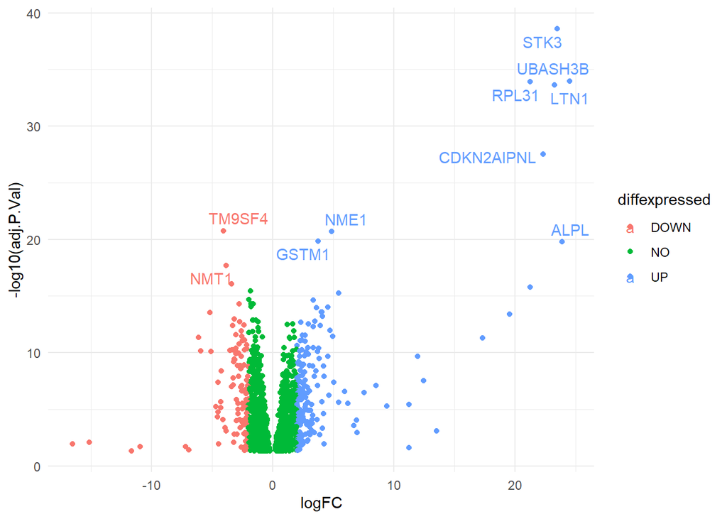

```r
volcano_list <- full_list

volcano1 <- ggplot(data = volcano_list, aes(x = data_experiment, y = -log10(adj.P.Val))) + geom_point()

volcano2 <- volcano1 + geom_vline(xintercept=c(-0.6, 0.6), col="red") +
  geom_hline(yintercept=-log10(0.05), col="red")

volcano_list$diffexpressed <- "NO"

volcano_list$diffexpressed[volcano_list$logFC > 2 & volcano_list$adj.P.Val < 0.05] <- "UP"

volcano_list$diffexpressed[volcano_list$logFC < -2 & volcano_list$adj.P.Val< 0.05] <- "DOWN"

volcanodif1 <- ggplot(data = volcano_list, aes(x = logFC, y = -log10(adj.P.Val), col = diffexpressed)) +
  geom_point() +
  theme_minimal() +
      geom_text_repel(data = volcano_list[1:10, ], aes(label = volcano_list[1:10, ]$Prot))


volcanodif1
```

Count number of DE proteins:

```r
length(which(volcano_list$logFC > 2 & volcano_list$adj.P.Val < 0.05))
```

```
## [1] 176
```

```r
length(which(volcano_list$logFC < -2 & volcano_list$adj.P.Val < 0.05))
```

```
## [1] 111
```

GO Enrichment analysis

```r
data_pv <- full_list[full_list$adj.P.Val < 0.05,]

data_pv_down <- data_pv[data_pv$logFC < -2,]

data_pv_up <- data_pv[data_pv$logFC > 2,]

write.csv(data_pv_down, "Prot_down.csv")
write.csv(data_pv_up, "Prot_up.csv")
```

GO enrichment analysis was performed using web-service https://biit.cs.ut.ee/gprofiler/.

Conclusion:

On the other hand, we observe processes and structures associated with cytoskeleton (e.g. actin filaments, intermediate filaments) among down-regulated terms. Together with down-regulated cell junction terms, it may possibly indicate that cells undergo serious shape and morphological changes. Among down-regulated proteins L-serine transport and metabolism enrichment terms were observed. We are not able to make a firm conclusion about the event, but it can be linked with lactic acid and nitrogen metabolism, which are key processes in heart cells.

Various GO terms associated with cell and protein localization and exosomes were among both up- and down-regulated proteins, they are very broad terms, which makes it hard to interprete these observations.